# Part II - Ford GoBike Trip Data Visualization

## by Mofeoluwa Jide-Jegede

## Investigation Overview

> The Questions for this analysis are designed to understand the best times to display advertisements to target specific people. What kind of reach would advertisements have on ford go bike users based on the patterns in the data?

> Some of the questions that would help understand this include:
> 1. What is the gender distribution across bike stations?
> 2. What are the busiest weekdays?
> 3. What is the busiest time of day for riders of different genders?
> 4. Age distribution of riders
> 5. Busiest stations at each time of the day
> 6. Most used bikes?

## Dataset Overview

> This data set includes information about individual rides made in a bike-sharing system covering the greater San Francisco Bay area for the month of February 2019.

> The dataset features information about **183412** rides with **16** variables.

> The variables represented by columns include:
> 1. Duration of trip(in seconds)
> 2. Start time,
> 3. End time,
> 4. Start_station_id
> 5. Start_station_name
> 6. Start_station_latitude
> 7. Start_station_longitude
> 8. End_station_id
> 9. End_station_name
> 10. End_station_latitude
> 11. End_station_longitude
> 12. Bike_id
> 13. User_type
> 14. Member_birth_year
> 15. Member_gender
> 16. Bike_share_for_all_trip.

## User Type Distribution

> The visualization of user type would help Ford GoBike to understand their consumers better and to decide how they could get more subscribers.

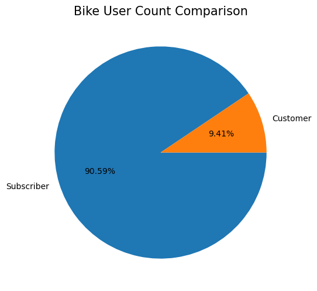

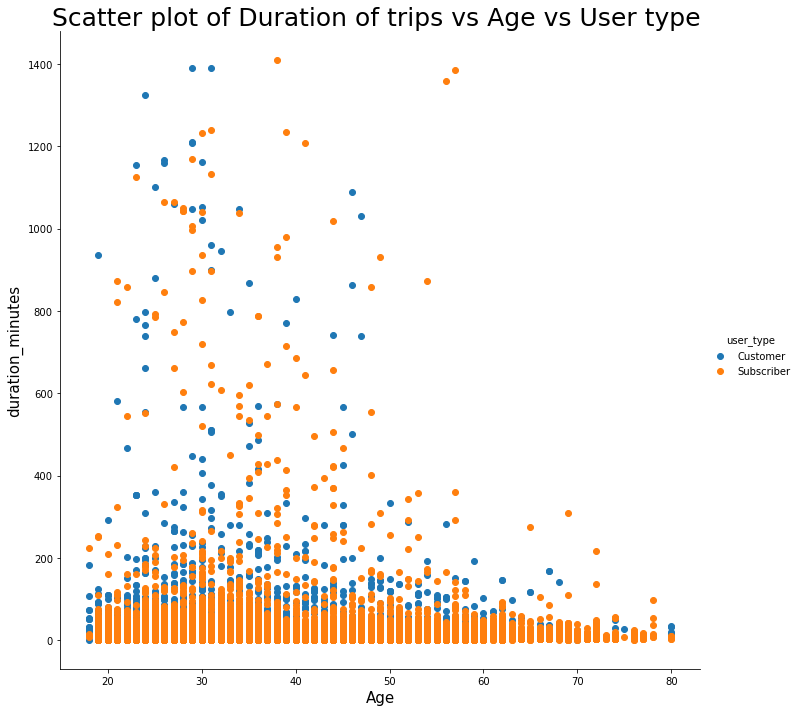

## Distribution of women riders in busiest stations

> The distribution of women in the busiest stations helps FordGobike to determine when and where ads targeted at woman would have the most effect.

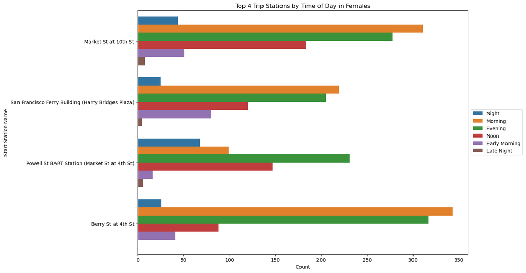

From the visualization, we can see that Berry St at 4th St has the most female riders in the mornings, followed by Market St at 10th St at that same time.

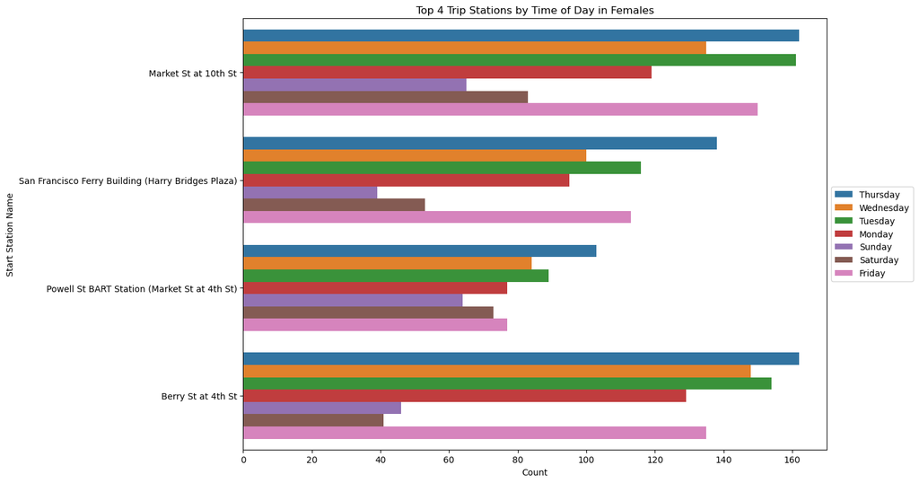

From the visualization above, we can see that Berry St at 4th St and Market St at 10th St has the most female riders on thursdays.

This tells us that for ads targeted to women the best location and time for the most reach is Berry St at 4th St on Thursday mornings.

## (Distribution of men riders in busiest stations)

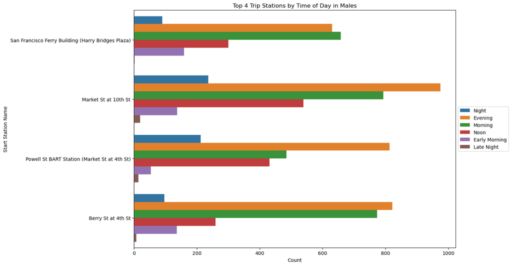

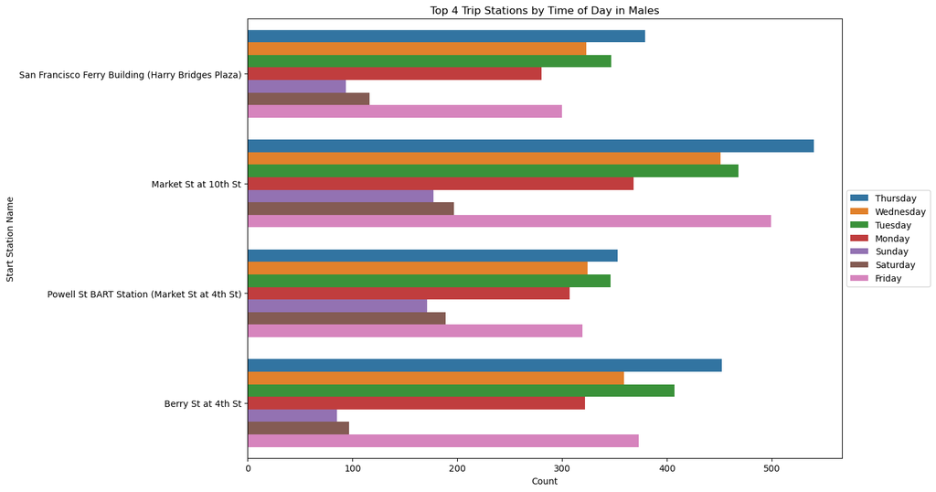

From the visualization above, we can see that Market St at 10th St has the most male riders on thursdays, followed by Berry St at 4th St on the same day.

## Age groups of Riders

> Through the mean age of riders we get an idea of the age group of riders at different times. This also helps to predict times that specific ads would reach certain age groups.

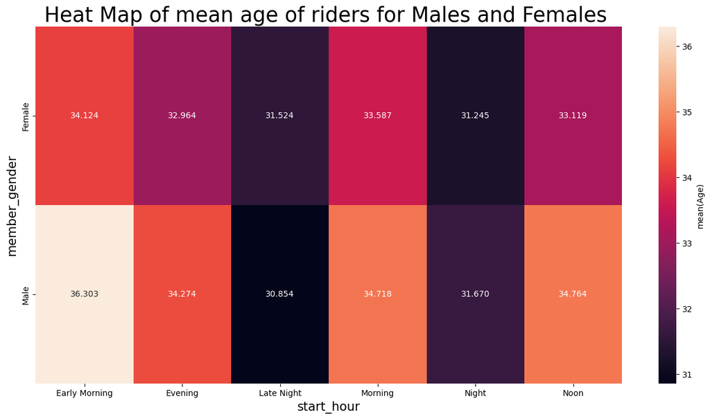

The heat map shows the mean ages of riders at different times of the day. It shows that, on average, older men ride in the early mornings, the same for women. It also shows that younger men are likely to ride late at night more. While younger women tend to ride more at night and late at night.

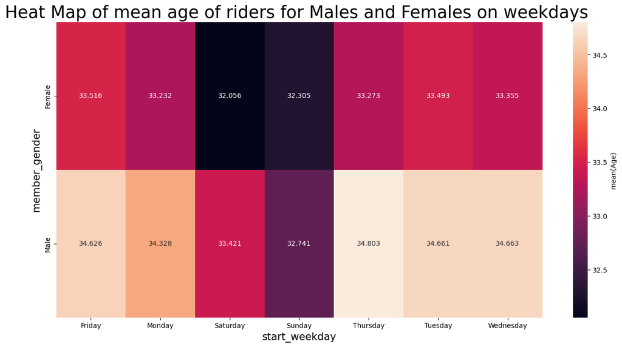

These heat maps tell us that to target older riders with ads it will be pointless to put up such an ad on the weekends at night.

## Most used bikes

> For the purpose of maintenance of bikes, we need to know the most used bikes based on number of trips and duration of trips.

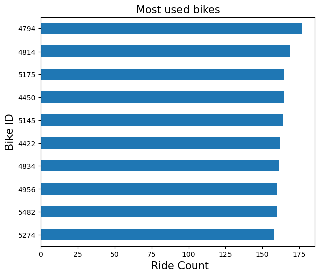

The bar plot shows the most used bikes according to the total number of trips the bike has done.

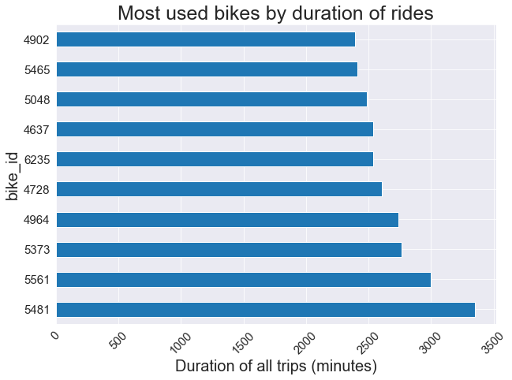

The bar plot shows the most used bikes according to the total duration of trips(in minutes), which i think is a better measure than number of trips.

However, based on what Ford GoBike decides as a policy, whether number of trips or duration of trips, the most used bikes should undergo maintenance.